# Brief solutions for the MATH3421 Practical Test

MAY 2023, AG HALF

Lab 3, Week 9

# Solutions to Q1

## 1.1

```r
k <- pcauchy(1)-pcauchy(0)
```

## 1.2

### 1.2(a)

```r
imp=function(N)
{
 x <- runif(N)
 k <- pcauchy(1)-pcauchy(0)
 return((1/N)*sum(x/(k*pi*(1+x^2))))
}
```

### 1.2(b)

```r
muhat <- imp(1000)
mu <- log(2)/(2*k*pi)
# Relative error of the mean versus ground truth:
abs(muhat-mu)/mu
```

```
## [1] 0.01037608
```

Good agreement (could also comment on error if desired).

### 1.2(c)

```r
self=function(N)
{
 x <- runif(N)
 wts <- dcauchy(x)
 return((1/sum(wts))*sum(x*wts))
}
```

### 1.2(d)

```r
mutilde <- self(1000)
# Relative error of the mean versus ground truth:
abs(mutilde-mu)/mu
```

```
## [1] 0.0130191
```

Prefer which estimator? Lots of possibilities e.g. self normalised estimator biased, but could have smaller variance etc.

### 1.2(e)

```r
self=function(N)
{
 x <- runif(N)
 wts <- dcauchy(x)
 print(mean(wts))
 return((1/sum(wts))*sum(x*wts))
}
```

Estimates $k$.

# Solutions to Q2

Read in the data etc.

```r
x <- c(0.942, 0.002, 0.904, 0.480, 0.597,
       0.009, 0.063, 0.033, 0.047, 0.001,
       0.172, 0.996, 0.743, 0.998, 0.278,
       0.549, 0.983, 0.005, 0.488, 0.816,
       0.893, 0.024, 0.976, 0.875, 0.913,
       0.349, 0.021, 0.894, 0.014, 0.995)
```

Helper function - simulates a single draw of a multivariate normal $N(m,V)$ random variable.

```r
rmvn=function(m,V)
{
 d <- length(m)
 z <- rnorm(d)
 return(m+t(chol(V))%*%z)
}
```

## 2.1

The completed function is:

```r
mh=function(N,sigma,x)
{
 mat <- matrix(0,ncol=2,nrow=N) #store theta samples in each row
 theta <- c(2/4,2/5) #initialise at prior mean
 mat[1,] <- theta
 for (i in 2:N)
   {
    can <- exp(rmvn(log(theta),sigma)) #Propose a candidate value
    #loglikeihood at candidate
    llikecan <- sum(dbeta(x,can[1],can[2],log=TRUE))
    #loglikelihood at current theta
    lliketheta <- sum(dbeta(x,theta[1],theta[2],log=TRUE))
    #log of prior at candidate
    lpriorcan <- sum(dgamma(can,c(2,2),c(4,5),log=TRUE))
    #log of prior at current theta
    lpriortheta <- sum(dgamma(theta,c(2,2),c(4,5),log=TRUE))
    #log acceptance probability
    laprob <- llikecan+lpriorcan-lliketheta-lpriortheta+
      sum(log(can))-sum(log(theta))
    #Includes Jacobian terms from proposal (RWM on log scale)
    u <- runif(1)
    if (log(u) < laprob)
    {
     theta <- can #Accept candidate
    }
    mat[i,] <- theta #Update chain
   }
 return(mat)
}
```

Careful here! The proposal mechanism operates on the log scale. Let $\psi_1=\log\theta_1$ and $\psi_2=\log\theta_2$. We have that the prior density for $\psi_1$ is

$$\pi(e^{\psi_1})e^{\psi_1}$$

and similarly for $\psi_2$. In the R code above, we therefore need a prior contribution in the (log) acceptance rate of the form

$$\log\pi(e^{\psi_1^*})+\log\pi(e^{\psi_2^*})+\psi_1^*+\psi_2^*-\log\pi(e^{\psi_1})-\log\pi(e^{\psi_2})-\psi_1-\psi_2$$

which can be written (in terms of $\theta_1$, $\theta_2$ $\theta_1^*$ and $\theta_2^*$) as

$$\log\pi(\theta_1^*)+\log\pi(\theta_2^*)+\log\theta_1^*+\log\theta_2^*-\log\pi(\theta_1)-\log\pi(\theta_2)-\log\theta_1-\log\theta_2$$
The code will still run without the (log) Jacobian terms and the output will look sensible, but ultimately incorrect! Note that I have chosen to include the Jacobian terms in the `laprob` evaluation, rather than in the evaluation of the log of the prior densities.

## 2.2

```r
out <- mh(5000,diag(c(0.1,0.1)),x)
```

```r
signew <- 0.5*(2.38^2)*var(log(out))
```

## 2.3

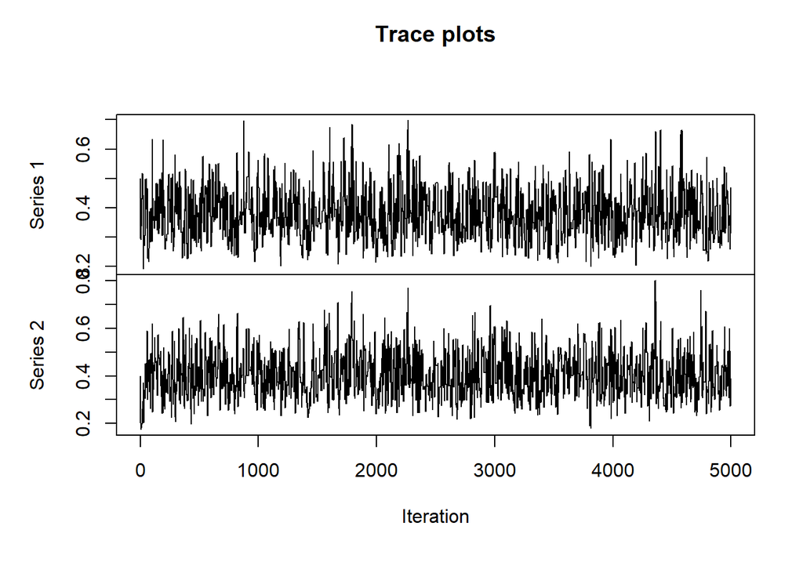

```r
out2 <- mh(5000,signew,x)
plot(ts(out2),main="Trace plots",xlab="Iteration") #Trace plots, could also give acf plots
```

```r
#summaries
summary(out[,1])
```

```
##    Min. 1st Qu.  Median    Mean 3rd Qu.    Max.
##  0.1771  0.3220  0.3786  0.3846  0.4381  0.6746
```

```r
summary(out[,2])
```

```
##    Min. 1st Qu.  Median    Mean 3rd Qu.    Max.
##  0.1635  0.3436  0.3995  0.4061  0.4648  0.7368
```

```r
cor(out[,1],out[,2]) #etc
```

```
## [1] 0.4309797
```

## 2.4

```r
m1 <- mean(out[,1])
m2 <- mean(out[,2])
m1/(m1+m2)
```

```
## [1] 0.4863965
```

Estimated CTR (ignoring posterior uncertainty) of around $50\%$. Fairly successful.

**Solutions to the second half of the test will be given in Term 2**